# FigureYa238corRiskMut

Xiaofan Lu

2025-5-20

# 需求描述

小丫老师，想众筹下FigA-C，预后模型建立后寻找高低风险组中突变最显著的基因，并计算riskscore与有义和错义突变的相关性，谢谢啦

# Requirement Description

Teacher Xiaoya, I want to crowdfund FigA-C, find the most significant mutations in the high and low risk groups after the prognostic model is established, and calculate the correlation between riskscore and sense and missense mutations, thank you

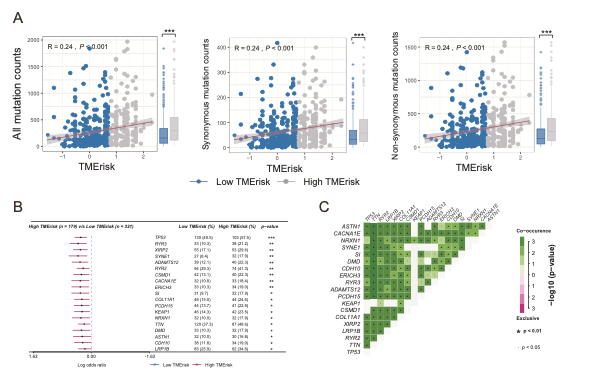

出自https://www.nature.com/articles/s41388-021-01853-y fromhttps://www.nature.com/articles/s41388-021-01853-y

Fig. 5 TMErisk was related to tumor mutation status. A Association between synonymous mutation counts, non-synonymous mutation counts, all mutation counts, and TMErisk score and their distribution in the low- and the high-TMErisk groups. B Forest plot of genes mutating differentially in patients of the low- and the high-TMErisk groups. C Interaction effect of genes mutating differentially in patients in the low- and the high-TMErisk groups.

**Mutation status in LUAD patients in the high- and the low-TMErisk groups**

To investigate **TMErisk-related mechanisms** in LUAD, somatic mutations from the TCGA database were also analyzed. When comparing the mutant frequency between samples of the low- and the high-TMErisk groups, **more somatic mutations were observed in the high-TMErisk group**, including non-synonymous and synonymous mutations (Fig. 5A). Meanwhile, maftools analysis results showed that 19 genes mutated more frequently in LUAD patients in the high- TMErisk group, including TP53, ASTN1, RYR2, XIRP2, LRP1B, CSMD1, RYR3, PCDH15, TTN, KEAP1, ADAMTS12, ERICH3, DMD, CDH10, SI, SYNE1, NRXN1, CACNA1E, and COL11A1 (Fig. 5B). Among these genes, eight were expressed differentially between the wild type and the mutant type (Fig. S8). The frequency of mutations in these genes was also shown in Fig. 4. Moreover, significant co-occurrences were observed among mutations of these genes (Fig. 5C).

# 应用场景

看到免疫浸润跟预后风险的关系，想进一步探究机制，例文作者从突变数据入手。

文章里有多个图可以用我们的FigureYa实现：

- Figure 2B 森林图，可参考FigureYa47HRtable和FigureYa193RiskTable；
- Figure 2C Time-dependent AUC，可参考FigureYa85timeROC；
- Figure 4 Landscape of immune and stromal cell infiltrations，可参考FigureYa230immunelandscape
- Figure 5D 对比的饼图，可参考FigureYa196PanPie

# Application Scenarios

Seeing the relationship between immune infiltration and prognostic risk, and wanting to further explore the mechanism, the author of the example article started with mutation data.

There are several diagrams in the article that can be implemented with our FigureYa:

- Figure 2B Forest Chart, see FigureYa47HRtable and FigureYa193RiskTable;
- Figure 2C Time-dependent AUC, see FigureYa85timeROC;
- Figure 4 Landscape of immune and stromal cell infiltrations, see FigureYa230immunelandscape
- For a pie chart compared to Figure 5D, see FigureYa196PanPie

# 环境设置

使用国内镜像安装包

# Environment settings

Use the domestic mirror installation packages

```r
options("repos"= c(CRAN="https://mirrors.tuna.tsinghua.edu.cn/CRAN/"))
options(BioC_mirror="http://mirrors.tuna.tsinghua.edu.cn/bioconductor/")
BiocManager::install("maftools")
```

```r
install.packages("ggplot2")
```

```
## Error in download.file(url, destfile, method, mode = "wb", ...) :
##   无法打开URL'https://mirrors.tuna.tsinghua.edu.cn/CRAN/bin/windows/contrib/4.4/ggplot2_3.5.2.zip'
```

加载包 load packages

```r
library(data.table)
library(maftools)
library(tidyverse)
library(magrittr)
```

```r
library(readxl)
library(stringr)
library(forcats)
library(ggplot2)
library(ggpubr)
library(cowplot)
library(patchwork)
Sys.setenv(LANGUAGE = "en") #显示英文报错信息 # error messages are displayed in English
options(stringsAsFactors = FALSE) #禁止chr转成factor # chr is not allowed to be converted to factor
```

# 输入文件

以下两个文件较大，已上传至微云https://share.weiyun.com/ks0OVM7a。建议按以下方式直接从官网下载：

- 表达数据：TCGA-LUAD.htseq_fpkm.tsv.gz，gene expression RNAseq - HTSeq - FPKM，下载自 [XENA](https://xenabrowser.net/datapages/) [GDC TCGA Lung Adenocarcinoma (LUAD) (15 datasets)](https://xenabrowser.net/datapages/?dataset=TCGA-LUAD.htseq_fpkm.tsv&host=https%3A%2F%2Fgdc.xenahubs.net&removeHub=https%3A%2F%2Fxena.treehouse.gi.ucsc.edu%3A443)，
- 突变数据：data_mutations_extended.txt，下载自[cBioPortal](http://www.cbioportal.org/datasets)，下载luad_tcga_pan_can_atlas_2018.tar.gz文件，解压缩把其中的data_mutations_extended.txt文件移到当前文件夹。

# Input files

The following two files are large and have been uploaded to the Weiyun https://share.weiyun.com/ks0OVM7a. It is recommended to download it directly from the official website in the following ways:

- Expression data :TCGA-LUAD.htseq_fpkm.tsv.gz, gene expression RNAseq - HTSeq - FPKM, downloaded from [XENA](https://xenabrowser.net/datapages/) [GDC TCGA Lung Adenocarcinoma (LUAD) (15 datasets)](https://xenabrowser.net/datapages/?dataset=TCGA-LUAD.htseq_fpkm.tsv&host=https://gdc.xenahubs.net&removeHub=https://xena.treehouse.gi.ucsc.edu:443)，
- :data_mutations_extended.txt mutation data, download it from [cBioPortal](http://www.cbioportal.org/datasets), download the luad_tcga_pan_can_atlas_2018.tar.gz file, unzip it, and put the data_mutations_ extended.txt move the file to the current folder.

[figure not shown]

```r
# 读取表达谱
# Read the expression spectrum
fpkm <- fread("TCGA-LUAD.htseq_fpkm.tsv.gz",sep = "\t",check.names = F,stringsAsFactors = F,header = T,data.table = F)
rownames(fpkm) <- fpkm[,1]; fpkm <- fpkm[,-1]

# 加载基因表达注释文件
# Load the gene expression annotation file
Ginfo <- read.table("gencode.v22.annotation.gene.probeMap",sep = "\t",row.names = 1,check.names = F,stringsAsFactors = F,header = T)

# 将FPKM的ENSEMBL ID转为Gene Symbol并去重
# Convert the ENSEMBL ID of the FPKM to Gene Symbol and remove the duplication
identical(rownames(Ginfo),rownames(fpkm))
```

```
## [1] FALSE
```

```r
comgene <- intersect(rownames(fpkm),rownames(Ginfo))
fpkm <- fpkm[comgene,]; Ginfo <- Ginfo[comgene,]
fpkm$Gene <- as.character(Ginfo$gene)
fpkm <- fpkm[!duplicated(fpkm$Gene),] # 重复基因去重 # Duplicate gene deduplication
rownames(fpkm) <- fpkm$Gene; fpkm <- fpkm[,-ncol(fpkm)]
fpkm <- as.data.frame(round(fpkm,3)) # 取表达的小数点后3位数 # Take 3 decimal places

# 取出肿瘤样本
# Tumor sample extraction
tumsam <- colnames(fpkm[,substr(colnames(fpkm),14,16) == "01A"])
```

```r
# 读取突变数据，并提取出和表达数据相同的样本
# Read the mutation data and extract the same sample as the expression data
label <- c("Tumor_Sample_Barcode",
           "Hugo_Symbol",
           "Chromosome",
           "Start_Position",
           "End_Position",
           "Variant_Classification",
           "Variant_Type",
           "Reference_Allele",
           "Tumor_Seq_Allele1",
           "Tumor_Seq_Allele2")
maf <- read_tsv("data_mutations_extended.txt", comment = "#")
maf$Tumor_Sample_Barcode <- paste0(maf$Tumor_Sample_Barcode,"A") # 添加"A"后缀以匹配突变 # Add the "A" suffix to match the mutation
comsam <- intersect(tumsam,unique(maf$Tumor_Sample_Barcode)) # 取出和表达相同的样本 # Extract samples with the same expression
maf <- maf[which(maf$Tumor_Sample_Barcode %in% comsam),label] # 取出样本和列子集 # Take out a subset of samples and columns
write.table(maf,"data_mutations_extended_modified.txt",sep = "\t",row.names = F,col.names = T,quote = F) # 输出文件
# Output file
```

# 计算TMEscore并分为高低两组

# The TMEscore is calculated and divided into two groups: high and low

```r
## 根据原文系数计算TMEscore
## The TMEscore is calculated based on the original coefficient
coeff <- c(0.7869,-0.4203,0.3138,-0.4006,0.6168,0.6100,-0.8024,-0.7196)
names(coeff) <- c("LOX","OR7E47P","SERPINE1","CX3CR1","GBP1","IRF1","STAP1","CD200R1")
is.element(names(coeff),rownames(fpkm))
```

```
## [1] TRUE TRUE TRUE TRUE TRUE TRUE TRUE TRUE
```

```r
indata <- fpkm[names(coeff),tumsam]
indata <- apply(indata, 1, function(x) ifelse(x > median(x), 1, 0)) # 原文将表达转换为二元变量 # The original text converts the expression into a binary variable
TME <- apply(indata,1,function(x) {x %*% as.numeric(coeff)}) # 根据lasso系数计算TME得分 # TME score is calculated based on the lasso coefficient
TMErisk <- data.frame(TME = TME,
                      risk = ifelse(TME > median(TME),"High","Low"),
                      row.names = names(TME),
                      stringsAsFactors = F)

## 分组，low- and the high-TMErisk groups
## grouping, low- and the high-TMErisk groups
hsam <- rownames(TMErisk[which(TMErisk$risk == "High"),])
lsam <- rownames(TMErisk[which(TMErisk$risk == "Low"),])
```

# 突变按non-synonymous and synonymous mutations分类

# Mutations are classified as non-synonymous and synonymous mutations

```r
# 提取low- and the high-TMErisk groups的MAF数据
# Extract MAF data from low- and the high-TMErisk groups
maf.high <- maf[which(maf$Tumor_Sample_Barcode %in% intersect(comsam,hsam)),] # 取出High-TME的MAF数据 # Retrieve the MAF data of High-TME
maf.low <- maf[which(maf$Tumor_Sample_Barcode %in% intersect(comsam,lsam)),] # 取出Low-TME的MAF数据 # Retrieve the MAF data of the Low-TME
write.table(maf.high,"data_mutations_extended_HRisk_modified.txt",sep = "\t",row.names = F,col.names = T,quote = F)
write.table(maf.low,"data_mutations_extended_LRisk_modified.txt",sep = "\t",row.names = F,col.names = T,quote = F)

# 突变按non-synonymous and synonymous mutations分类
# 再次读取maf文件提取突变类型
# Mutations are classified as non-synonymous and synonymous mutations
# Read the maf file again to extract the mutation type
maf <- read.maf("data_mutations_extended_modified.txt") # 重新读取子集 # Re-read the subset
```

```
## -Reading
## -Validating
## --Removed 17294 duplicated variants
## -Silent variants: 62938
## -Summarizing
## --Possible FLAGS among top ten genes:
##   TTN
##   MUC16
##   USH2A
##   FLG
## -Processing clinical data
## --Missing clinical data
## -Finished in 3.460s elapsed (1.050s cpu)
```

```r
synMut <- as.character(unique(maf@maf.silent$Variant_Classification)) # 利用maftool的功能取出定义的沉默突变类型 # Use the function of maftool to get out the defined mutation type of silence
nsynMut <- as.character(unique(maf@data$Variant_Classification)) # 取出maftool定义的非沉默突变类型 # Take out the non-silencing mutation types defined by maftool
allMut <- c(synMut,nsynMut) # 合并得到全部突变类型 # Merge to get all mutation types

# 重新读取MAF对象
# Re-read the MAF object
synMut.ob <- read.maf("data_mutations_extended_modified.txt",
                      vc_nonSyn = synMut, # 将非沉默类型定义为“沉默突变”，这样返回的对象在“非沉默突变”里记载的就是“沉默突变”，因此会计算沉默突变的TMB # Define the non-silent type as "silent mutation", so that the returned object is recorded in the "non-silent mutation" as "silent mutation", so the TMB of the silent mutation will be calculated
                      removeDuplicatedVariants = F)
```

```
## -Reading
## -Validating
## -Silent variants: 151483
## -Summarizing
## --Possible FLAGS among top ten genes:
##   TTN
##   MUC16
##   USH2A
##   DST
## -Processing clinical data
## --Missing clinical data
## -Finished in 3.260s elapsed (1.250s cpu)
```

```r
nsynMut.ob <- read.maf("data_mutations_extended_modified.txt",
                       vc_nonSyn = nsynMut, # 同理 # Same
                       removeDuplicatedVariants = F)
```

```
## -Reading
## -Validating
## -Silent variants: 68148
## -Summarizing
## --Possible FLAGS among top ten genes:
##   TTN
##   MUC16
##   USH2A
##   FLG
## -Processing clinical data
## --Missing clinical data
## -Finished in 3.060s elapsed (1.020s cpu)
```

```r
allMut.ob <- read.maf("data_mutations_extended_modified.txt",
                      vc_nonSyn = allMut, # 同理 # Same
                      removeDuplicatedVariants = F)
```

```
## -Reading
## -Validating
## -Summarizing
## --Possible FLAGS among top ten genes:
##   TTN
##   MUC16
##   USH2A
## -Processing clinical data
## --Missing clinical data
## -Finished in 3.360s elapsed (0.980s cpu)
```

```r
synMut.TMB <- as.data.frame(synMut.ob@variants.per.sample); rownames(synMut.TMB) <- synMut.TMB$Tumor_Sample_Barcode; synMut.TMB <- synMut.TMB[comsam,]
nsynMut.TMB <- as.data.frame(nsynMut.ob@variants.per.sample); rownames(nsynMut.TMB) <- nsynMut.TMB$Tumor_Sample_Barcode; nsynMut.TMB <- nsynMut.TMB[comsam,]
allMut.TMB <- as.data.frame(allMut.ob@variants.per.sample); rownames(allMut.TMB) <- allMut.TMB$Tumor_Sample_Barcode; allMut.TMB <- allMut.TMB[comsam,]

# 合并突变信息、高低风险
# Combined mutation information, high and low risk
synMut.TMB <- cbind.data.frame(synMut.TMB,TMErisk[rownames(synMut.TMB),c("risk","TME")]); synMut.TMB$risk <- factor(synMut.TMB$risk, levels = c("Low","High"))
head(synMut.TMB)
```

```
##                  Tumor_Sample_Barcode Variants risk     TME
## TCGA-MP-A4T4-01A     TCGA-MP-A4T4-01A      145  Low -0.4017
## TCGA-05-4250-01A     TCGA-05-4250-01A      153 High  2.3275
## TCGA-64-5774-01A     TCGA-64-5774-01A       60 High  0.3666
## TCGA-97-7937-01A     TCGA-97-7937-01A      150  Low -0.4203
## TCGA-97-A4M6-01A     TCGA-97-A4M6-01A       17  Low -1.7329
## TCGA-44-A4SU-01A     TCGA-44-A4SU-01A       61  Low -1.9226
```

```r
nsynMut.TMB <- cbind.data.frame(nsynMut.TMB,TMErisk[rownames(nsynMut.TMB),c("risk","TME")]); nsynMut.TMB$risk <- factor(nsynMut.TMB$risk, levels = c("Low","High"))
allMut.TMB <- cbind.data.frame(allMut.TMB,TMErisk[rownames(allMut.TMB),c("risk","TME")]); allMut.TMB$risk <- factor(allMut.TMB$risk, levels = c("Low","High"))
```

# 图A

该图分左中右三个图，每个图包含左侧相关性散点图和右侧箱型图。

# Figure A

The graph is divided into three plots, left, middle and right, each of which contains a correlation scatter plot on the left and a box plot on the right.

Association between **synonymous mutation counts, non-synonymous mutation counts, all mutation counts**, and **TMErisk score and their distribution** in the **low- and the high-TMErisk groups**.

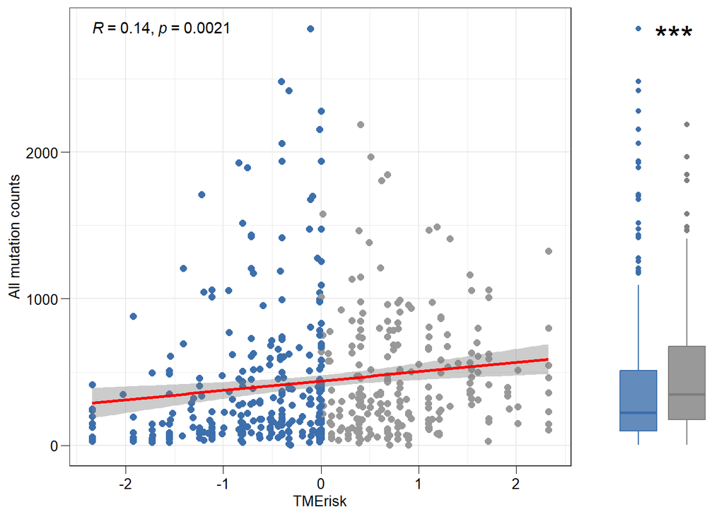

```r
# 左图 - 所有突变all mutation counts
# 相关性散点图
# Left panel - all mutation counts
# Correlation scatter plot
p1 <- ggscatter(allMut.TMB,
          x = "TME", y = "Variants",
          color = "risk",
          palette = c(Low = "#3C6FAC",High = "grey60"),
          add = "reg.line",
          add.params = list(color = "red", fill = "grey50"),
          conf.int = TRUE) +
  stat_cor(method = "pearson", label.x = min(na.omit(allMut.TMB$TME)), label.y = max(na.omit(allMut.TMB$Variants))) +
  theme_bw() +
  ylab("All mutation counts") +
  xlab("TMErisk") +
  theme(axis.text.x = element_text(hjust = 0.5, size = 10, color = "black"),
        axis.text.y = element_text(size = 10, color = "black"),
        axis.ticks = element_line(size=0.2, color="black"),
        axis.ticks.length = unit(0.2, "cm"),
        legend.position = "none",
        panel.background = element_blank(),
        axis.title = element_text(size = 10),
        axis.text = element_text(size = 10))
# 箱型图
# boxplot
p2 <- ggplot(na.omit(allMut.TMB), aes(x = risk, y = Variants, fill = risk)) +
  geom_boxplot(aes(col = risk)) +
  scale_fill_manual(values = alpha(c("#3C6FAC","grey50"),0.8)) +
  scale_color_manual(values = c("#3C6FAC","grey50")) +
  xlab("") + ylab("") +
  theme_bw() +
  theme(legend.position = "none",
        legend.title = element_blank(),
        axis.text.x = element_blank(),
        axis.text.y = element_blank(),
        axis.ticks = element_blank(),
        panel.border = element_blank(),
        panel.grid = element_blank(),
        panel.background = element_blank(),
        axis.title = element_text(size = 10),
        axis.text = element_text(size = 10)) +
  stat_compare_means(method = "wilcox.test", label = "p.signif", label.y = max(na.omit(allMut.TMB$Variants)) * 0.95, label.x = 1.5, size = 8)

# 合并图像
# Merge images
plot_grid(p1, p2,
          labels = c("","",""), # 无图例 # No legend
          rel_widths = c(0.8,0.2), # 左边散点图大一些，右边小一些 # The scatter plot on the left is larger, and the right is smaller
          axis = "tblr", # 四周对齐 # Align all sides
          align = 'h', # 水平摆放 # Horizontally
          ncol = 2, # 两列 # Two columns
          scale = c(1,1), greedy = T)
```

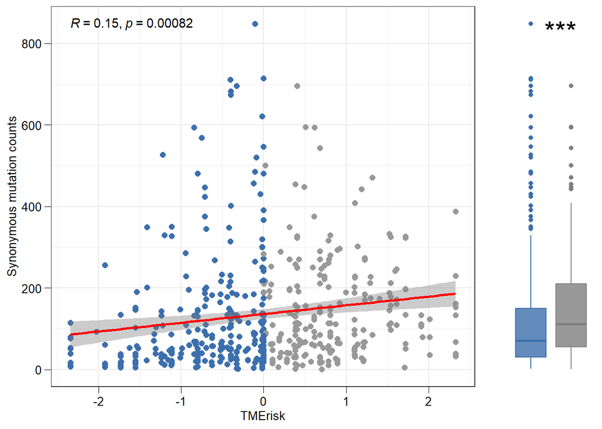

```r
ggsave(filename = "scatter and boxplot for all mutation counts.pdf", width = 5,height = 4)

# 中间的图 - 沉默突变synonymous mutation counts
# 相关性散点图
# Graph in the middle - Silent mutation synonymous mutation counts
# Correlation scatter plot
p1 <- ggscatter(synMut.TMB,
                x = "TME", y = "Variants",
                color = "risk",
                palette = c(Low = "#3C6FAC",High = "grey60"),
                add = "reg.line",
                add.params = list(color = "red", fill = "grey50"),
                conf.int = TRUE) +
  stat_cor(method = "pearson", label.x = min(na.omit(synMut.TMB$TME)), label.y = max(na.omit(synMut.TMB$Variants))) +
  theme_bw() +
  ylab("Synonymous mutation counts") +
  xlab("TMErisk") +
  theme(axis.text.x = element_text(hjust = 0.5, size = 10, color = "black"),
        axis.text.y = element_text(size = 10, color = "black"),
        axis.ticks = element_line(size=0.2, color="black"),
        axis.ticks.length = unit(0.2, "cm"),
        legend.position = "none",
        panel.background = element_blank(),
        axis.title = element_text(size = 10),
        axis.text = element_text(size = 10))

# 箱型图
# boxplot
p2 <- ggplot(na.omit(synMut.TMB), aes(x = risk, y = Variants, fill = risk)) +
  geom_boxplot(aes(col = risk)) +
  scale_fill_manual(values = alpha(c("#3C6FAC","grey50"),0.8)) +
  scale_color_manual(values = c("#3C6FAC","grey50")) +
  xlab("") + ylab("") +
  theme_bw() +
  theme(legend.position = "none",
        legend.title = element_blank(),
        axis.text.x = element_blank(),
        axis.text.y = element_blank(),
        axis.ticks = element_blank(),
        panel.border = element_blank(),
        panel.grid = element_blank(),
        panel.background = element_blank(),
        axis.title = element_text(size = 10),
        axis.text = element_text(size = 10)) +
  stat_compare_means(method = "wilcox.test", label = "p.signif", label.y = max(na.omit(synMut.TMB$Variants)) * 0.95, label.x = 1.5, size = 8)

# 合并图像
# Merge images
plot_grid(p1, p2,
          labels = c("","",""),
          rel_widths = c(0.8,0.2),
          axis = "tblr",
          align = 'h',ncol = 2,scale = c(1,1), greedy = T)
```

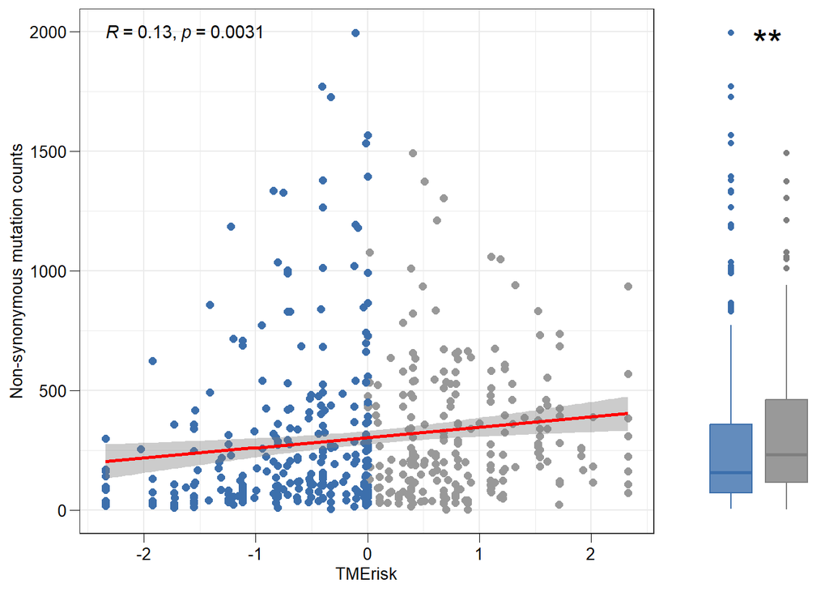

```r
ggsave(filename = "scatter and boxplot for synonymous mutation counts.pdf", width = 5,height = 4)

# 右图 - 非沉默突变 non-synonymous mutation counts
# 相关性散点图
# Right panel - non-synonymous mutation counts
# Correlation scatter plot
p1 <- ggscatter(nsynMut.TMB,
                x = "TME", y = "Variants",
                color = "risk",
                palette = c(Low = "#3C6FAC",High = "grey60"),
                add = "reg.line",
                add.params = list(color = "red", fill = "grey50"),
                conf.int = TRUE) +
  stat_cor(method = "pearson", label.x = min(na.omit(nsynMut.TMB$TME)), label.y = max(na.omit(nsynMut.TMB$Variants))) +
  theme_bw() +
  ylab("Non-synonymous mutation counts") +
  xlab("TMErisk") +
  theme(axis.text.x = element_text(hjust = 0.5, size = 10, color = "black"),
        axis.text.y = element_text(size = 10, color = "black"),
        axis.ticks = element_line(size=0.2, color="black"),
        axis.ticks.length = unit(0.2, "cm"),
        legend.position = "none",
        panel.background = element_blank(),
        axis.title = element_text(size = 10),
        axis.text = element_text(size = 10))

# 箱型图
# boxplot
p2 <- ggplot(na.omit(nsynMut.TMB), aes(x = risk, y = Variants, fill = risk)) +
  geom_boxplot(aes(col = risk)) +
  scale_fill_manual(values = alpha(c("#3C6FAC","grey50"),0.8)) +
  scale_color_manual(values = c("#3C6FAC","grey50")) +
  xlab("") + ylab("") +
  theme_bw() +
  theme(legend.position = "none",
        legend.title = element_blank(),
        axis.text.x = element_blank(),
        axis.text.y = element_blank(),
        axis.ticks = element_blank(),
        panel.border = element_blank(),
        panel.grid = element_blank(),
        panel.background = element_blank(),
        axis.title = element_text(size = 10),
        axis.text = element_text(size = 10)) +
  stat_compare_means(method = "wilcox.test", label = "p.signif", label.y = max(na.omit(nsynMut.TMB$Variants)) * 0.95, label.x = 1.5, size = 8)

# 合并图像
# Merge images
plot_grid(p1, p2,
          labels = c("","",""),
          rel_widths = c(0.8,0.2),
          axis = "tblr",
          align = 'h',ncol = 2,scale = c(1,1), greedy = T)
```

```r
ggsave(filename = "scatter and boxplot for non-synonymous mutation counts.pdf", width = 5,height = 4)
```

# image B

Forest plot of genes mutating differentially in patients of the low- and the high-TMErisk groups.

```r
allMut.hrisk.ob <- read.maf("data_mutations_extended_HRisk_modified.txt", # 重新读取High TME的MAF文件 # Re-read the MAF file of High TME
                            vc_nonSyn = nsynMut, # 按照原文的结果应该是用的非沉默突变 # According to the original result, it should be used with non-silencing mutations
                            removeDuplicatedVariants = F)
```

```
## -Reading
## -Validating
## -Silent variants: 32347
## -Summarizing
## --Possible FLAGS among top ten genes:
##   TTN
##   MUC16
##   USH2A
## -Processing clinical data
## --Missing clinical data
## -Finished in 1.620s elapsed (0.700s cpu)
```

```r
allMut.lrisk.ob <- read.maf("data_mutations_extended_LRisk_modified.txt",
                            vc_nonSyn = nsynMut,
                            removeDuplicatedVariants = F)
```

```
## -Reading
## -Validating
## -Silent variants: 35801
## -Summarizing
## --Possible FLAGS among top ten genes:
##   TTN
##   MUC16
##   USH2A
##   FLG
## -Processing clinical data
## --Missing clinical data
## -Finished in 1.750s elapsed (0.610s cpu)
```

```r
h.vs.l <- mafCompare(m1 = allMut.lrisk.ob,
                     m2 = allMut.hrisk.ob,
                     m1Name = 'Low TMErisk',
                     m2Name = 'High TMErisk',
                     minMut = 30) # 按照原文的图，最少突变应该不少于30个 # According to the original diagram, there should be at least 30 mutations
write.table(as.data.frame(h.vs.l$results),file = "fisher test regarding non-synonymous mutations of TME risk group.txt",sep = "\t",row.names = F,col.names = T,quote = F)
pdf("forestplot.pdf", width = 8,height = 6)
forestPlot(mafCompareRes = h.vs.l, pVal = 0.05) # 保留检验显著的结果 # Retain the results of the test
invisible(dev.off())
```

[figure not shown]

# 图C

#image C

Interaction effect of genes mutating differentially in patients in the low- and the high-TMErisk groups.

```r
tmp <- as.data.frame(h.vs.l$results)
pdf("mutual exclusivity plot.pdf", width = 6,height = 6)
res <- somaticInteractions(maf = nsynMut.ob,
                           genes = as.character(tmp[tmp$pval < 0.05,"Hugo_Symbol"]),# 取出上面分析得到的显著基因 # substract the salient genes from the above analysis
                           showCounts = FALSE, # 不展示OR值 # The OR value is not displayed
                           showSum = FALSE, # 不展示突变综述 # Mutation reviews are not shown
                           pvalue = c(0.05, 0.01), # p值的区间（原文这里也有问题，P<0.05显著的是.，但是这个函数好像没有修改的参数） # The interval of the p-value (there is also a problem here in the original text, P<0.05 is significant, but this function does not seem to have modified the parameters)
                           colPal = "PiYG") # 选择原文配色 # Select the color scheme of the original text
invisible(dev.off())
write.table(as.data.frame(res),file = "mutual exclusivity test regarding non-synonymous mutations.txt",sep = "\t",row.names = F,col.names = T,quote = F)
```

[figure not shown]